# Chapter 1 discussion questions

DATASCI/STATS 531

1. **Fitting to different time intervals.** In chapter 1, we saw results for ARMA models fitted to two different time intervals. Here are the full R fitted model summaries for data up to 2018 and 2020:

```r
y <- read.table(file="ann_arbor_weather.csv",header=1)
arma2018 <- arima(y$Low[y$Year<=2018], order=c(1,0,1))
arma2018
```

```
##
## Call:
## arima(x = y$Low[y$Year <= 2018], order = c(1, 0, 1))
##
## Coefficients:
##          ar1      ma1  intercept
##       0.8257  -0.7881    -2.8193
## s.e.  0.2650   0.2866     0.8080
##
## sigma^2 estimated as 53.06:  log likelihood = -401.76,  aic = 811.52
```

```r
arma2020 <- arima(y$Low[y$Year<=2020], order=c(1,0,1))
arma2020
```

```
##
## Call:
## arima(x = y$Low[y$Year <= 2020], order = c(1, 0, 1))
##
## Coefficients:
##           ar1      ma1  intercept
##       -0.0005  -0.0005    -2.8086
## s.e.  13.1214  13.2431     0.6842
##
## sigma^2 estimated as 56.16:  log likelihood = -411.97,  aic = 831.93
```

What do you conclude by comparing these fitted models? Do you notice anything surprising?

2. **Diagnostics.** We plotted the residuals and we checked their autocorrelation, but we did not do a normality test on them. We could have done a Shapiro-Wilk test,

```r
y <- read.table(file="ann_arbor_weather.csv",header=1)
r <-  arima(y$Low, order=c(1,0,1))$resid
shapiro.test(r)
```

```
##
##  Shapiro-Wilk normality test
##
## data:  r
## W = 0.99418, p-value = 0.8922
```

We could confirm that the residuals have an approximatedly normal marginal distribution, for example

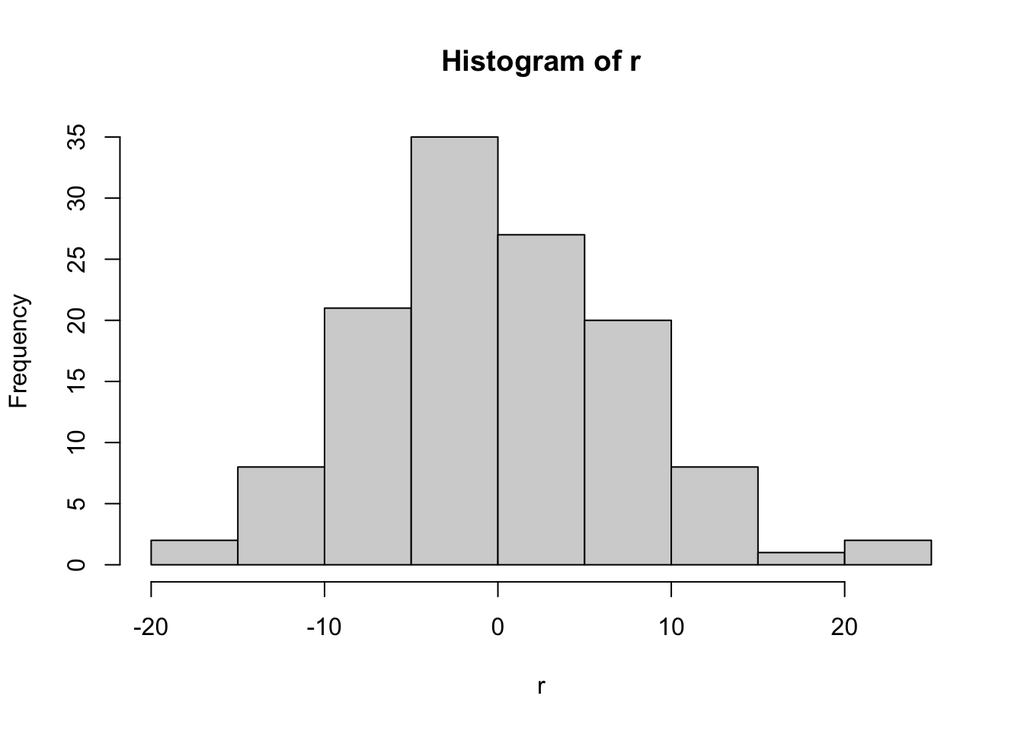

```r
hist(r)
```

The importance of normality may depend on what we want to do with the resulting fitted model. For many purposes, a central limit result may make results insensitive to normality. Severe outliers may nevertheless be important, and plotting the residuals can help to identify these.

What purposes for a fitted model might be more—or less—sensitive to normality?

If you’re curious to read more about this, Section 3.10 of [Box (1976)](https://doi.org/10.1080/01621459.1976.10480949) gives an example where addressing dependence is much more important than non-normality.

3. **Changing variation**. Perhaps climate change in Michigan January low temperature is primarily in the variability rather than the expected value? Let’s look for a trend in absolute deviation.

```r
y <- read.table(file="ann_arbor_weather.csv",header=1)$Low
year <- seq_along(y)-1 # year since 1900
ad <- abs(y-median(y,na.rm=TRUE))
lm.ad <- lm(ad~year)
summary(lm.ad)
```

```
##
## Call:
## lm(formula = ad ~ year)
##
## Residuals:
##     Min      1Q  Median      3Q     Max
## -6.9934 -3.3128 -0.6988  2.8033 15.5023
##
## Coefficients:
##             Estimate Std. Error t value Pr(>|t|)
## (Intercept)  4.71299    0.79788   5.907 3.23e-08 ***
## year         0.01983    0.01110   1.786   0.0766 .
## ---
## Signif. codes:  0 '***' 0.001 '**' 0.01 '*' 0.05 '.' 0.1 ' ' 1
##
## Residual standard error: 4.479 on 122 degrees of freedom
##   (1 observation deleted due to missingness)
## Multiple R-squared:  0.02547,    Adjusted R-squared:  0.01749
## F-statistic: 3.189 on 1 and 122 DF,  p-value: 0.07662
```

This is borderline significant, so maybe we are onto something. Perhaps the change in variability will be clearer if we separate it from the possible change in expected value:

```r
y <- read.table(file="ann_arbor_weather.csv",header=1)$Low
year <- seq_along(y)-1 # year since 1900
y.na <- is.na(y)
y <- y[!y.na]
year <- year[!y.na]
y2 <- resid(lm(y~year+I(year^2)+I(year^3)))
ad2 <- abs(y2-median(y2))
lm.ad2 <- lm(ad2~year)
summary(lm.ad2)
```

```
##
## Call:
## lm(formula = ad2 ~ year)
##
## Residuals:
##     Min      1Q  Median      3Q     Max
## -6.8807 -3.2359 -0.8642  2.3473 15.6314
##
## Coefficients:
##             Estimate Std. Error t value Pr(>|t|)
## (Intercept)  4.46909    0.79646   5.611 1.28e-07 ***
## year         0.02306    0.01108   2.081   0.0395 *
## ---
## Signif. codes:  0 '***' 0.001 '**' 0.01 '*' 0.05 '.' 0.1 ' ' 1
##
## Residual standard error: 4.471 on 122 degrees of freedom
## Multiple R-squared:  0.03427,    Adjusted R-squared:  0.02636
## F-statistic:  4.33 on 1 and 122 DF,  p-value: 0.03955
```

We have statistical significance at the 5% level, but have we p-hacked? How would you assess this?